# Multi-Path AIC Model Selection

# 3 Stability Estimation (Bootstrap)

```r
# Estimate stability using 50 bootstrap replicates
res_stability <- stability(
  data = train_data,
  response = "Diagnosis",
  B = 50,
  K = 5,
  delta = 2,
  L = 50,
  model_type = "logistic"
)

# Print top stable features
print(res_stability)
```

```
## path_stability object
## B = 50 | predictors = 9 | model_type = logistic
##          feature         pi
##        Cell.size 0.83522222
##      Bare.nuclei 0.76070468
##     Cl.thickness 0.38572938
##       Cell.shape 0.20747447
##      Bl.cromatin 0.17890065
##    Marg.adhesion 0.15260839
##  Normal.nucleoli 0.09309402
##          Mitoses 0.08689694
##     Epith.c.size 0.04380037
```

## 3.1 Stability Visualization

The variable stability plot shows how frequently each predictor appears across bootstrap samples. High stability indicates robust predictors that consistently contribute to good model fits.

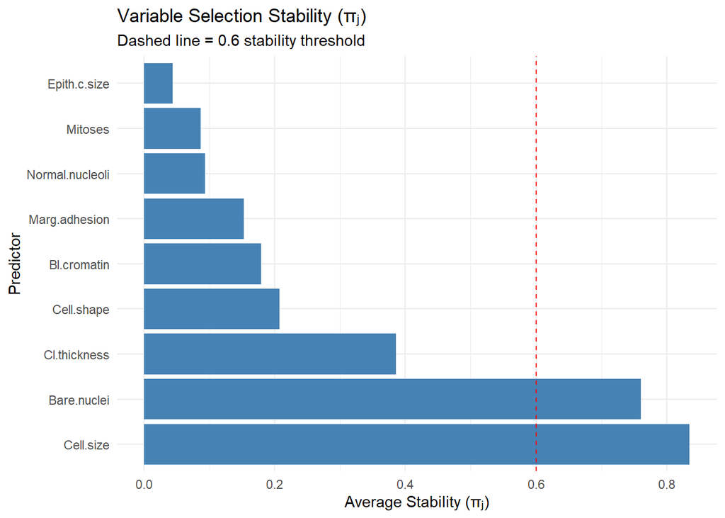

```r
# Visualize stability scores
library(ggplot2)

# Prepare data frame for plotting
stab_df <- data.frame(
  Predictor = names(res_stability$pi),
  Stability = res_stability$pi
)

stab_df <- stab_df %>%
  arrange(desc(Stability)) %>%
  mutate(Predictor = factor(Predictor, levels = Predictor))  # preserve order

# Plot
ggplot(stab_df, aes(x = Predictor, y = Stability)) +
  geom_col(fill = "steelblue") +
  geom_hline(yintercept = 0.6, linetype = "dashed", color = "red") +
  labs(
    title = "Variable Selection Stability (πⱼ)",
    subtitle = "Dashed line = 0.6 stability threshold",
    y = "Average Stability (πⱼ)",
    x = "Predictor"
  ) +
  coord_flip() +
  theme_minimal()
```

*Interpretation:*

From Figure, Bare.nuclei and Cell.size exhibit the highest stability, each appearing in the majority of bootstrap-selected models. This suggests that these predictors are the most reliable and consistently associated with breast cancer classification outcomes.

Variables such as Cl.thickness and Cell.shape show moderate stability, implying that they may contribute to the model in some bootstrap samples but are not universally strong predictors.

Overall, the stability plot highlights Bare.nuclei and Cell.size as the most critical and reproducible predictors across resampled models.

# 4 Select Plausible Models (AIC + Stability)

```r
# Filter plausible models with AIC + Stability thresholds
plausible <- select_plausible_models(
  full_data_models = res_logistic,
  stability_obj = res_stability,
  delta_AIC = 2,
  tau = 0.5,
  keep_fits = TRUE
)

# Show resulting plausible models
print(plausible)
```

[output not shown]

```r
# plotting
#ggplot(stab_df, aes(x = Stability)) +
#  geom_histogram(binwidth = 0.05, fill = "purple", color = "white") +
 # geom_vline(xintercept = 0.6, color = "red", linetype = "dashed") +
#  labs(title = "Distribution of Predictor Stabilities", x = "πⱼ", y = "Count")
```